Skip to main content

# Predicting Tea Category from Tea Characteristics

Author

Clarissa Nada Dahjan | Julia Gorospe | Kangju Sun | Yingwen Liu

# Summary

In this project we ask whether a Chinese tea’s caffeine level can be used to predict its category. The dataset has eight categories: green, white, yellow, oolong, black, dark, pu’er and scented tea. Using The [Chinese Tea Dataset](https://chinatea.house/dataset/), which describes 136 named Chinese teas, we train a decision tree classifier that uses caffeine level (low, moderate or high) as its predictor. We compare it against a baseline that always predicts the most common category (oolong, 25% of teas), and a decision tree with three features: caffeine level, body, and oxidation level. This matters because shops and drinkers often treat the tea types as a guide to caffeine levels. If category cannot be recovered from caffeine, that rule of thumb is unreliable, and people limiting caffeine should not rely on tea type alone.

# Introduction

Tea is a major source of caffeine and is highly consumed in China. Caffeine intake of up to 400 mg per day does not raise health concerns for healthy adults ([Yong et al., 2022](https://pubmed.ncbi.nlm.nih.gov/35513285/)), but people who are sensitive to caffeine, or who need to limit it, have to judge how much they are taking in. Tea drinkers often use a tea’s category as a rough guide, assuming for example that white and green teas are low in caffeine and black teas are high. However, caffeine content varies with tea variety, geographical origin and season ([Zhang et al., 2022](https://www.maxapress.com/article/id/62e78ad3ce60b94f990b397f)), and a nationwide study of Chinese teas found that average caffeine content differed only modestly between categories, from about 27 mg/g for oolong to 43 mg/g for yellow tea ([Yong et al., 2022](https://pubmed.ncbi.nlm.nih.gov/35513285/)).

In this project, we use a machine learning algorithm to predict a Chinese tea’s category (for example green, oolong or black tea) given its caffeine level. Answering this question is important because it tests how reliable category is as a guide to caffeine. If caffeine level strongly predicts category, the two carry overlapping information and category is a reasonable shortcut. If it does not, the common rule of thumb is unreliable, and people limiting their caffeine should look for caffeine information directly rather than relying on tea type.

To answer this question, we use [The Chinese Tea Dataset](https://chinatea.house/dataset/). It contains 136 named Chinese teas, such as Xi Hu Longjing and Menghai 7542, each described by 11 columns: an identifier, English and Chinese names, category, growing region, caffeine level, body, oxidation level, main flavour notes, a short written description and a tier. Caffeine level is recorded as one of three values: low, moderate or high. The target we want to predict is the tea’s category, which has eight classes: green, white, yellow, oolong, black, dark, pu’er and scented tea.

```python
from pathlib import Path
import requests
import pandas as pd

def get_project_root(marker: str = "pyproject.toml") -> Path:
  current = Path.cwd().resolve()
  for parent in [current, *current.parents]:
    if (parent / marker).exists():
      return parent

project_root = get_project_root()

# create the data folders if they don't exist
# (git does not track empty folders)
raw_dir = project_root / "data" / "raw"
processed_dir = project_root / "data" / "processed"
raw_dir.mkdir(parents=True, exist_ok=True)
processed_dir.mkdir(parents=True, exist_ok=True)

# download the data if we don't already have a copy
url = "https://chinatea.house/data/chinese-tea-dataset.csv"
data_path = raw_dir / "chinese-tea-dataset.csv"

if not data_path.exists():
    request = requests.get(url)
    request.raise_for_status()
    data_path.write_bytes(request.content)

# read in data
tea = pd.read_csv(data_path)
print(f"Samples: {tea.shape[0]}; Features: {tea.shape[1]}")
tea.head()
```

```
Samples: 136; Features: 11
```

|  | id | name_en | name_zh | category | region | caffeine_level | body | oxidation_level | flavor_primary | description_brief | tier |
| --- | --- | --- | --- | --- | --- | --- | --- | --- | --- | --- | --- |
| 0 | alishan-oolong | Alishan High Mountain Oolong | 阿里山乌龙 | Oolong Tea | Alishan | moderate | medium | 0.20 | floral,butter,cream | Lightly oxidized oolong from Taiwan's Alishan ... | 1 |
| 1 | anji-bai-cha | Anji Bai Cha (Anji White Tea) | 安吉白茶 | Green Tea | Anji County | low | light | 0.02 | umami,chestnut,bamboo | A unique green tea (not white, despite the nam... | 1 |
| 2 | bai-hao-yinzhen | Bai Hao Yin Zhen (Silver Needle) | 白毫银针 | White Tea | Fuding | low | light | 0.08 | melon,honey,hay | The highest grade of white tea, made exclusive... | 1 |
| 3 | bai-mudan | Bai Mudan (White Peony) | 白牡丹 | White Tea | Fuding | low | light-medium | 0.10 | floral,honey,hay | White tea featuring one bud and two leaves, of... | 1 |
| 4 | biluochun | Biluochun (Green Snail Spring) | 碧螺春 | Green Tea | Dongting Mountain | moderate | light | 0.02 | fruity,floral,fresh | Prized spring green tea from Dongting Mountain... | 1 |

# Methods

Using the dataset downloaded in the Introduction section, we evaluate our primary research question: **Can caffeine level alone serve as a reliable predictor of tea category?**

### Data Preprocessing and Exploratory Data Analysis

First, we remove unique identifiers and sparse attributes, retaining only the target variable (category) and three core features (caffeine level, body, and oxidation level). Although the primary flavor could also provide information, we exclude it here to keep the feature space compact.

```python
from sklearn.model_selection import train_test_split

clean_tea = tea[["category", "caffeine_level", "body", "oxidation_level"]]
clean_path = processed_dir / "clean_tea.csv"
clean_tea.to_csv(clean_path, index=False)

clean_tea.head()
```

|  | category | caffeine_level | body | oxidation_level |
| --- | --- | --- | --- | --- |
| 0 | Oolong Tea | moderate | medium | 0.20 |
| 1 | Green Tea | low | light | 0.02 |
| 2 | White Tea | low | light | 0.08 |
| 3 | White Tea | low | light-medium | 0.10 |
| 4 | Green Tea | moderate | light | 0.02 |

Next, we split the cleaned dataset into an 80% training set and a 20% test set. To strictly follow to the **Golden Rule** and prevent data leakage, we perform all exploratory data analysis and model selection exclusively on the training data.

```python
result = {}

caffeine_level_order = ["low", "moderate", "high"]
body_order = ["light", "light-medium", "medium", "medium-full", "full"]

X = clean_tea.drop(columns=["category"])
y = clean_tea["category"]

X_train, X_test, y_train, y_test = train_test_split(
    X, y, test_size=0.2, random_state=42
)

train_df = pd.concat([X_train, y_train], axis=1)
summary_table = (
    train_df.groupby("category", as_index=False)
    .agg(
        count=("category", "size"),
        most_frequent_caffeine=("caffeine_level", lambda x: x.mode().iloc[0]),
        most_frequent_body=("body", lambda x: x.mode().iloc[0]),
        mean_oxidation=("oxidation_level", "mean"),
    )
    .round({"mean_oxidation": 3})
)

summary_table
```

|  | category | count | most_frequent_caffeine | most_frequent_body | mean_oxidation |
| --- | --- | --- | --- | --- | --- |
| 0 | Black Tea | 16 | moderate | medium | 0.950 |
| 1 | Dark Tea | 5 | low | full | 0.830 |
| 2 | Green Tea | 25 | moderate | light-medium | 0.020 |
| 3 | Oolong Tea | 28 | moderate | medium | 0.416 |
| 4 | Pu'er Tea | 13 | high | full | 0.297 |
| 5 | Scented Tea | 7 | moderate | light | 0.243 |
| 6 | White Tea | 11 | low | medium | 0.106 |
| 7 | Yellow Tea | 3 | moderate | light-medium | 0.107 |

From the training summary table, several tea categories share the exact same caffiene level, whereas the mean oxidation varies across categories. This strongly suggests that relying only on caffeine level will likely result in underfitting.

While the summary table shows that several tea categories share the exact same most frequent caffeine level, looking only at the mode hides how much categories overlap across the full distribution. To inspect the complete spread of caffeine levels across each tea category, we plot the category counts below.

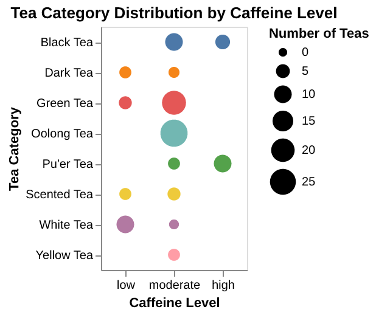

```python
import altair as alt
alt.renderers.enable('png', scale_factor=2.0)

chart = (
    alt.Chart(train_df, width = 120, height = 200)
    .mark_circle()
    .encode(
        x=alt.X(
            "caffeine_level:N",
            title="Caffeine Level",
            sort=caffeine_level_order,
            axis=alt.Axis(labelAngle=0),
        ),
        y=alt.Y("category:N", title="Tea Category"),
        size=alt.Size(
            "count():Q",
            title="Number of Teas",
            scale=alt.Scale(range=[50, 500]),
        ),
        color=alt.Color("category:N", legend=None),
    )
    .properties(
        title="Tea Category Distribution by Caffeine Level",
    )
)

chart
```

**Figure 1.** Tea category distribution by caffeine level category.

Caffeine level alone will not perform well as a predictor due to heavy class overlap. Notably, all eight tea categories appear in the moderate column, where Green Tea and Oolong Tea are most heavily concentrated.

## Baseline Model: Dummy Classifier

To establish a performance benchmark, we first fit a dummy classifier that always predicts the most frequent tea category in the training set.

```python
from sklearn.dummy import DummyClassifier
from sklearn.model_selection import cross_val_score

dummy = DummyClassifier(strategy="most_frequent")
dummy.fit(X_train, y_train)

result["Dummy"] = {
    "Train Score": dummy.score(X_train, y_train),
    "CV Score": cross_val_score(dummy, X_train, y_train, cv=3, scoring="accuracy").mean()
}
print(f"Chosen {dummy.predict(X_test[:1])[0]}.")

def print_score(model):
    for name, value in result[model].items():
        print(f"{name}: {value:.3}")
print_score("Dummy")
```

```
Chosen Oolong Tea.
Train Score: 0.259
CV Score: 0.259
```

As expected, the baseline model has very low cross-validation accuracy due to severe underfitting, confirming the need for a more complex model.

## Single-Feature Model: Decision Tree (Caffeine Level Only)

Because our feature space has discrete ordinal levels and clear domain thresholds, a Decision Tree Classifier is a interpretable choice. To directly answer our research question, we first train a decision tree using **only** caffeine level while dropping all other features, tuning the tree depth by 3-fold cross-validation.

```python
from sklearn.pipeline import make_pipeline
from sklearn.compose import make_column_transformer
from sklearn.preprocessing import OrdinalEncoder
from sklearn.model_selection import GridSearchCV
from sklearn.tree import DecisionTreeClassifier

caffeine_preprocessor = make_column_transformer(
    (OrdinalEncoder(categories=[caffeine_level_order]), ["caffeine_level"],),
    remainder="drop"
)

tree = GridSearchCV(
    make_pipeline(caffeine_preprocessor, DecisionTreeClassifier(random_state=42)),
    param_grid={"decisiontreeclassifier__max_depth": list(range(1, 5))},
    cv=3,
    scoring="accuracy",
    return_train_score=True,
    n_jobs=-1,
)
tree.fit(X_train, y_train)

result["Caffeine-Only Decision Tree"] = {
    "Train Score": tree.cv_results_["mean_train_score"][tree.best_index_],
    "CV Score": tree.best_score_
}

print("Best tree depth:", tree.best_params_['decisiontreeclassifier__max_depth'])
print_score("Caffeine-Only Decision Tree")
```

```
Best tree depth: 2
Train Score: 0.444
CV Score: 0.444
```

While using caffeine level improves validation accuracy over the dummy baseline, the overall predictive performance remains weak. Caffeine level alone is insufficient to reliably distinguish between tea categories.

## Full Mode: Decision Tree (All Features)

```python
full_preprocessor = make_column_transformer(
    (
        OrdinalEncoder(categories=[caffeine_level_order, body_order]),
        ["caffeine_level", "body"],
    ),
    remainder="passthrough",
)

full_tree = GridSearchCV(
    make_pipeline(full_preprocessor, DecisionTreeClassifier(random_state=42)),
    param_grid={"decisiontreeclassifier__max_depth": list(range(1, 10))},
    cv=3,
    scoring="accuracy",
    return_train_score=True,
    n_jobs=-1,
)
full_tree.fit(X_train, y_train)

result["Full Decision Tree"] = {
    "Train Score": full_tree.cv_results_["mean_train_score"][full_tree.best_index_],
    "CV Score": full_tree.best_score_
}

print("Best tree depth:", full_tree.best_params_['decisiontreeclassifier__max_depth'])
print_score("Full Decision Tree")
```

```
Best tree depth: 6
Train Score: 0.944
CV Score: 0.88
```

Comparing validation results across all three models shows a great jump in validation accuracy once body and oxidation level are included. Having selected the **Full Decision Tree** as our best-performing model based on cross-validation, we evaluate it once on the held-out test set to obtain an unbiased estimate:

```python
test_score = full_tree.score(X_test, y_test)

result["Full Decision Tree"]["Test Score"] = test_score
print(f"Full Tree Test Score: {test_score:.3}")
```

```
Full Tree Test Score: 0.786
```

# Results

We compared three models to evaluate how well they predict tea category. Table 1 shows their mean cross-validation accuracy on the training data. The test accuracy is also reported for the selected full decision tree.

**Table 1. Classification accuracy of the three models.**

```python
from IPython.display import display

results_table = pd.DataFrame(result)
num_cols = results_table.select_dtypes(include="number").columns
results_table[num_cols] = results_table[num_cols].map(
    lambda x: f"{x:.1%}" if pd.notna(x) else "N/A"
)
display(results_table)
```

|  | Dummy | Caffeine-Only Decision Tree | Full Decision Tree |
| --- | --- | --- | --- |
| Train Score | 25.9% | 44.4% | 94.4% |
| CV Score | 25.9% | 44.4% | 88.0% |
| Test Score | N/A | N/A | 78.6% |

## Validation Accuracy Comparison

Figure 2 compares the mean cross-validation accuracy of the three models.

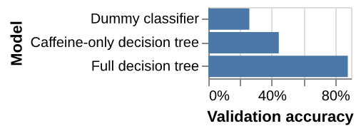

```python
import altair as alt

plot_data = pd.DataFrame({
    "Model": ["Dummy classifier", "Caffeine-only decision tree", "Full decision tree"],
    "Validation accuracy": [
        result["Dummy"]["CV Score"],
        result["Caffeine-Only Decision Tree"]["CV Score"],
        result["Full Decision Tree"]["CV Score"]
    ]
})

chart = alt.Chart(plot_data, width = 100, height = 50).mark_bar().encode(
    y=alt.Y("Model:N", sort='x', title="Model"),
    x=alt.X("Validation accuracy:Q", title="Validation accuracy",
            axis=alt.Axis(format=".0%"))
)

chart
```

**Figure 2.** Mean three-fold cross-validation accuracy of the three classification models on the training data.

In Figure 2, the caffeine only decision tree has a mean validation accuracy of 44.4%, while the full decision tree is 88.0%. This suggests that caffeine level alone is not sufficient to predict tea category. Adding body and oxidation level can improve prediction accuracy.

## Analysis of Misclassification

**Table 2a. Confusion matrix for predicted tea types using only caffiene-level.**

```python
import numpy as np
from sklearn.metrics import confusion_matrix

predictions = tree.predict(X_test)
labels = np.array([label.removesuffix(' Tea') for label in tree.classes_])


confus_matrix = pd.DataFrame(
    confusion_matrix(y_test, predictions),
    index=[f"Actual {label}" for label in labels],
    columns=[f"{label}" for label in labels]
)

confus_matrix
```

|  | Black | Dark | Green | Oolong | Pu'er | Scented | White | Yellow |
| --- | --- | --- | --- | --- | --- | --- | --- | --- |
| Actual Black | 0 | 0 | 0 | 4 | 0 | 0 | 0 | 0 |
| Actual Dark | 0 | 0 | 0 | 3 | 0 | 0 | 1 | 0 |
| Actual Green | 0 | 0 | 0 | 4 | 0 | 0 | 1 | 0 |
| Actual Oolong | 0 | 0 | 0 | 6 | 0 | 0 | 0 | 0 |
| Actual Pu'er | 0 | 0 | 0 | 2 | 1 | 0 | 0 | 0 |
| Actual Scented | 0 | 0 | 0 | 2 | 0 | 0 | 2 | 0 |
| Actual White | 0 | 0 | 0 | 0 | 0 | 0 | 1 | 0 |
| Actual Yellow | 0 | 0 | 0 | 1 | 0 | 0 | 0 | 0 |

**Table 2b. Confusion matrix for predicted tea types using caffiene-level, body, and oxidation-level.**

```python
full_predictions = full_tree.predict(X_test)

full_confus_matrix = pd.DataFrame(
    confusion_matrix(y_test, full_predictions),
    index=[f"Actual {label}" for label in labels],
    columns=[f"{label}" for label in labels]
)

full_confus_matrix
```

|  | Black | Dark | Green | Oolong | Pu'er | Scented | White | Yellow |
| --- | --- | --- | --- | --- | --- | --- | --- | --- |
| Actual Black | 4 | 0 | 0 | 0 | 0 | 0 | 0 | 0 |
| Actual Dark | 0 | 3 | 0 | 0 | 1 | 0 | 0 | 0 |
| Actual Green | 0 | 0 | 5 | 0 | 0 | 0 | 0 | 0 |
| Actual Oolong | 0 | 0 | 0 | 6 | 0 | 0 | 0 | 0 |
| Actual Pu'er | 0 | 0 | 0 | 1 | 2 | 0 | 0 | 0 |
| Actual Scented | 0 | 1 | 1 | 1 | 0 | 0 | 1 | 0 |
| Actual White | 0 | 0 | 0 | 0 | 0 | 0 | 1 | 0 |
| Actual Yellow | 0 | 0 | 0 | 0 | 0 | 0 | 0 | 1 |

The all features model show a better performance on tea category classification. However, with current limited features, the tea category Scented is hard to classify. We may introduce the primary flavor as a feature in further analysis.

## Caffeine Levels Across Tea Categories

Figure 3 shows the caffeine levels across tea categories in the training data.

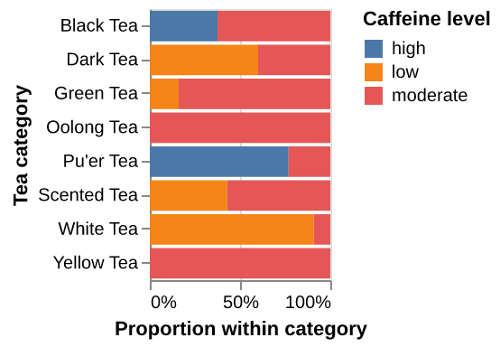

```python
import altair as alt

chart2 = alt.Chart(train_df, width = 100, height = 150).mark_bar().encode(
    y=alt.Y("category:N", title="Tea category"),
    x=alt.X("count():Q", stack="normalize",
            title="Proportion within category",
            axis=alt.Axis(format=".0%")),
    color=alt.Color("caffeine_level:N", title="Caffeine level")
)

chart2
```

**Figure 3.** The distribution of caffeine levels of each tea category.

Figure 3 shows that different tea types can have similar caffeine levels. For example, green tea and scented tea both have low and moderate levels. Black tea and pu’er tea both have moderate and high levels. This shows why it is hard to predict tea type using only caffeine level.

# Discussion

The 3-level caffeine category did not distinguish tea category well. From Table 2a it is clear that there is difficultly differentiating any tea from the oolong category based on caffeine level alone. Adding information about tea body and oxidation level improved the ability to accurately identify a tea category.

For individuals looking to limit their caffeine intake, using tea categories alone may not be a precise proxy for caffeine content. Beyond variation in caffeine levels within a category, method of tea preparation also impacts available caffeine content ([Oliveira, 2012](https://doi.org/10.1590/S0101-20612012005000009)). Tea drinkers may want to assess more characteristics of a tea when selecting a variety than simply the tea category or caffeine level. The oxidation level plays a large role in the flavour of a tea which may influence preferences in taste aside from caffeine content ([Chen et al., 2021](https://doi.org/10.1016/j.foodres.2021.110613)). For example, green teas have low oxidation levels because they are heat treated after harvest to kill the enzymes that complete the process while white and black teas have higher oxidation levels because they are allowed to dry naturally.

The results of the decision tree classifier confirmed our expectation that caffeine level would not predict tea category well. However, the analysis is limited by the coarseness of the caffeine categories and class imbalance favouring the moderate category. A more granular or even a numeric caffeine level could change the conclusion of this analysis. The dataset is relatively small with a fair bit of class imbalance which may hinder the performance of a decision tree classifier. Additional methods for weighting the classes may be difficult to implement given the size of some of the categories.

Given the context of the introduction and the most common concern tea drinkers may have, it may be more valuable to further assess the efficacy of predicting caffeine-level from other tea factors. Oxidation level is a stronger single-feature candidate for predicting tea category because traditional tea classifications is closely related to oxidation ranges. For the future plan, fit a simple decision tree on each candidate feature separately using cross-validation, comparing accuracy against the baseline model.

# References

Chen, L., Liu, F., Yang, Y., Tu, Z., Lin, J., Ye, Y., Xu, P. (2021). Oxygen-enriched fermentation improves the taste of black tea by reducing the bitter and astringent metabolites. *Food Research International, 148, Article 110613. Available from: https://doi.org/10.1016/j.foodres.2021.110613

China Tea House. Chinese Tea Dataset. Accessed Nov 16, 2026. Available from: https://chinatea.house/dataset/

Oliveira, Rafaela. (2012). Quantification of catechins and caffeine from green tea (Camellia sinensis) infusions, extract, and ready-to-drink beverages. Food Science and Technology. 32. 163-166. 10.1590/S0101-20612012005000009.

Yong, L., Song, Y., Xiao, X., Sui, H., Xu, H., Tan, R., Yang, X., Song, J., Li, J., & Wei, S. (2022). Quantitative probabilistic assessment of caffeine intake from tea in Chinese adult consumers based on nationwide caffeine content determination and tea consumption survey. *Food and Chemical Toxicology, 165*, Article 113102. https://doi.org/10.1016/j.fct.2022.113102

Zhang, S., Jin, J., Chen, J., Ercisli, S., & Chen, L. (2022). Purine alkaloids in tea plants: Component, biosynthetic mechanism and genetic variation. *Beverage Plant Research, 2*, Article 13. https://doi.org/10.48130/BPR-2022-0013